# Chapter 02 Problems - Using rstudio

# Load Libraries

Only need to run the following installs once. Therefore commented after the first run.

```r
#install.packages(c("readxl","ggplot2", "ggpubr", "tidyverse", "broom", "AICcmodavg"))
```

```r
library(readxl)
library(ggplot2)
library(ggpubr)
library(tidyverse)
library(broom)
library(AICcmodavg)
```

## Functions

```r
PlotBands <- function(DataFrame, LinearModel, ...){
    #get predicted y values using regression equation
    newx <- seq(min(DataFrame$x), max(DataFrame$x), length.out=100)

    #calculate the confidence interval values
    conf <- predict(LinearModel, newdata = data.frame(x=newx), interval = 'confidence', level=0.95)

    #calculate the prediction interval values
    pred <- predict(LinearModel, newdata = data.frame(x=newx), interval = 'predict', level=0.95)

    #create plot of x vs. y, but don't display individual points (type='n')
    ########### Add flexibility to this plot function..
    plot(y ~ x, data = DataFrame, type='n', ylim=c(min(pred[,2]),max(pred[,3])),...)
    #############

    #add polygon: Confidence Interval Upper -> Prediction Interval Upper
    polygon(c(rev(newx), newx), c(rev(conf[ ,3]), pred[ ,3]), col = 'pink', border = NA)

    #add polygon: Predicted Values -> Confidence Interval Upper
    polygon(c(rev(newx), newx), c(rev(conf[ ,3]), conf[ ,1]), col = 'gray85', border = NA)

    #add polygon: Predicted Values -> Confidence Interval Lower
    polygon(c(rev(newx), newx), c(rev(conf[ ,2]), pred[ ,2]), col = 'pink', border = NA)

    #add polygon: Confidence Interval Lower -> Prediction Interval Lower
    polygon(c(rev(newx), newx), c(rev(conf[ ,2]), conf[ ,1]), col = 'gray85', border = NA)

    #add line: Regression
    abline(LinearModel, lwd=1.5)

    #add line: Confidence Interval Upper
    lines(newx, conf[ ,3], lty = 'dashed', col = 'gray5', lwd=1.5)
    #add line: Confidence Interval Lower
    lines(newx, conf[ ,2], lty = 'dashed', col = 'gray5', lwd=1.5)

    #add line: Prediction Interval Upper
    lines(newx, pred[ ,3], lty = 'dashed', col = 'red4', lwd=1.5)
    #add line: Prediction Interval Upper
    lines(newx, pred[ ,2], lty = 'dashed', col = 'red4', lwd=1.5)
}

LMStandardAnalysis <- function(DataFrame, LinearModel, Probability, AddLine=TRUE, ...){
  ReturnList = list()
  ReturnList$Summary <- summary(LinearModel)
  ReturnList$Anova <- anova(LinearModel)
  ReturnList$MSres <- ReturnList$Anova['Residuals','Mean Sq']
  ReturnList$RSqrd <- ReturnList$Summary$r.squared
  ReturnList$t_0 <- ReturnList$Summary$coefficients['x','t value']
  ReturnList$t_alpha <- qt(Probability, df=nrow(DataFrame))
  ReturnList$t_RejectNull <- (abs(ReturnList$t_0) > ReturnList$t_alpha)
  ReturnList$fstatistic <- unname(ReturnList$Summary$fstatistic[1])
  ReturnList$pvalue <- ReturnList$Summary$coefficients['x','Pr(>|t|)']
  ReturnList$Intercept <- ReturnList$Summary$coefficients['(Intercept)','Estimate']
  ReturnList$Slope <- ReturnList$Summary$coefficients['x','Estimate']

  plot(DataFrame$x, DataFrame$y,...)
  if(AddLine){
    abline(LinearModel)
  }
  return(ReturnList)

}
```

# Problems

## 2.16

```r
Pressure <- list()

Pressure$DataTable <- read_excel('../linear_regression_5e_data_sets/Chapter 2/Problems/data-prob-2-16.xls')

Pressure$df <- data.frame(
    x=Pressure$DataTable$'Volume',
    y=Pressure$DataTable$'Pressure')

head(Pressure$df)
```

```
##      x    y
## 1 2084 4599
## 2 2084 4600
## 3 2273 5044
## 4 2273 5043
## 5 2273 5044
## 6 2463 5488
```

```r
Pressure$lm <- lm(y ~ x, data=Pressure$df)
```

```r
PressureLM <- LMStandardAnalysis(Pressure$df, Pressure$lm, Probability = .975, xlab="Volume", ylab="Pressure")
```

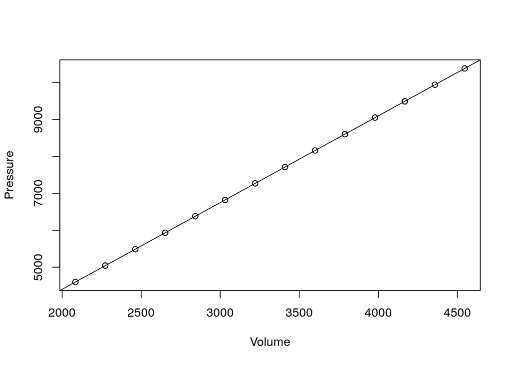

```r
PressureLM
```

```
## $Summary
##
## Call:
## lm(formula = y ~ x, data = Pressure$df)
##
## Residuals:
##     Min      1Q  Median      3Q     Max
## -4.3276 -0.9227  0.0773  1.2676  2.9577
##
## Coefficients:
##               Estimate Std. Error t value Pr(>|t|)
## (Intercept) -2.907e+02  1.355e+00  -214.6   <2e-16 ***
## x            2.346e+00  4.007e-04  5855.4   <2e-16 ***
## ---
## Signif. codes:  0 '***' 0.001 '**' 0.01 '*' 0.05 '.' 0.1 ' ' 1
##
## Residual standard error: 1.741 on 31 degrees of freedom
## Multiple R-squared:      1,  Adjusted R-squared:      1
## F-statistic: 3.429e+07 on 1 and 31 DF,  p-value: < 2.2e-16
##
##
## $Anova
## Analysis of Variance Table
##
## Response: y
##           Df    Sum Sq   Mean Sq  F value    Pr(>F)
## x          1 103947022 103947022 34286009 < 2.2e-16 ***
## Residuals 31        94         3
## ---
## Signif. codes:  0 '***' 0.001 '**' 0.01 '*' 0.05 '.' 0.1 ' ' 1
##
## $MSres
## [1] 3.031762
##
## $RSqrd
## [1] 0.9999991
##
## $t_0
## [1] 5855.426
##
## $t_alpha
## [1] 2.034515
##
## $t_RejectNull
## [1] TRUE
##
## $fstatistic
## [1] 34286009
##
## $pvalue
## [1] 2.982258e-95
##
## $Intercept
## [1] -290.7066
##
## $Slope
## [1] 2.346432
```

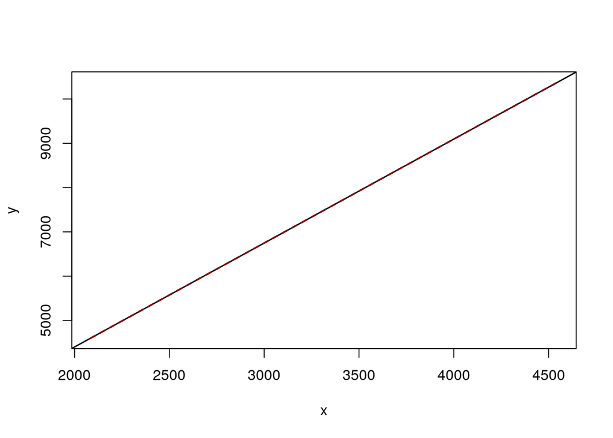

```r
PlotBands(Pressure$df, Pressure$lm)
```

The result of the linear model analysis confirms that this is a perfect relationship. * The RSquared term is ~1 and the Residual Mean Squared is extremely small. * The confidence intervals are extremely small, essentially non existent. * We reject the Null hypothesis This set of data essentially describes a perfect relationship.

## 2.17

```r
BarometricPressure <- list()

BarometricPressure$DataTable <- read_excel('../linear_regression_5e_data_sets/Chapter 2/Problems/data-prob-2-17.xls')

BarometricPressure$df <- data.frame(
    y=BarometricPressure$DataTable$'Boiling Point (F)',
    x=BarometricPressure$DataTable$'Barometric Pressure (in Hg)')

head(BarometricPressure$df)
```

```
##       y     x
## 1 199.5 20.79
## 2 199.3 20.79
## 3 197.9 22.40
## 4 198.4 22.67
## 5 199.4 23.15
## 6 199.9 23.35
```

```r
BarometricPressure$lm <- lm(y ~ x, data=BarometricPressure$df)
```

```r
BarometricPressureLM <- LMStandardAnalysis(BarometricPressure$df, BarometricPressure$lm, Probability = .975,
                                           ylab="Boiling Point (F)", xlab="Barometric Pressure (in Hg)")
```

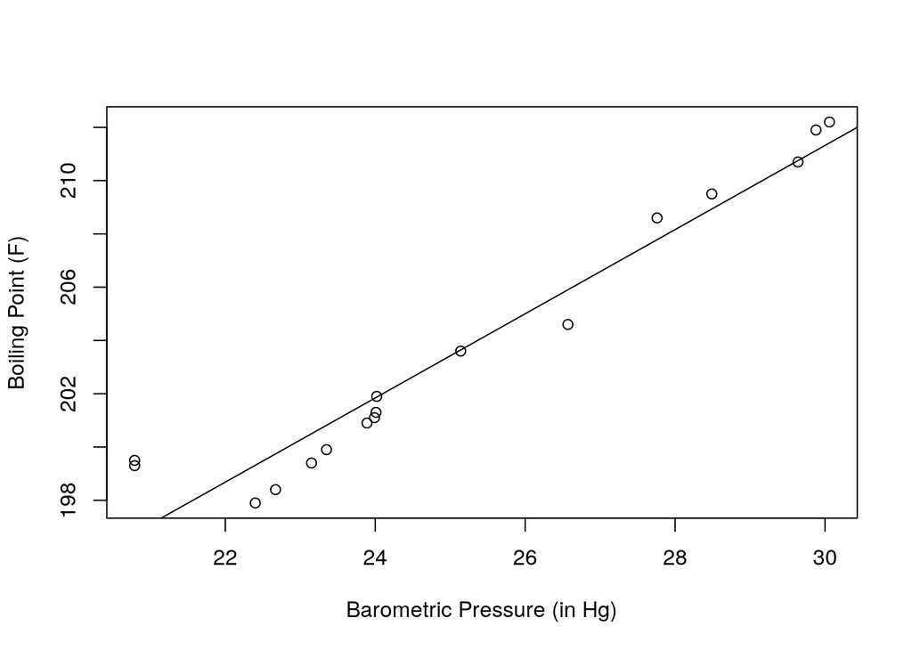

```r
BarometricPressureLM
```

```
## $Summary
##
## Call:
## lm(formula = y ~ x, data = BarometricPressure$df)
##
## Residuals:
##      Min       1Q   Median       3Q      Max
## -1.41483 -0.91550 -0.05148  0.76941  2.72840
##
## Coefficients:
##             Estimate Std. Error t value Pr(>|t|)
## (Intercept) 163.9307     2.6551   61.74  < 2e-16 ***
## x             1.5796     0.1051   15.04 1.88e-10 ***
## ---
## Signif. codes:  0 '***' 0.001 '**' 0.01 '*' 0.05 '.' 0.1 ' ' 1
##
## Residual standard error: 1.291 on 15 degrees of freedom
## Multiple R-squared:  0.9378, Adjusted R-squared:  0.9336
## F-statistic:   226 on 1 and 15 DF,  p-value: 1.879e-10
##
##
## $Anova
## Analysis of Variance Table
##
## Response: y
##           Df Sum Sq Mean Sq F value    Pr(>F)
## x          1 376.92  376.92  226.04 1.879e-10 ***
## Residuals 15  25.01    1.67
## ---
## Signif. codes:  0 '***' 0.001 '**' 0.01 '*' 0.05 '.' 0.1 ' ' 1
##
## $MSres
## [1] 1.667494
##
## $RSqrd
## [1] 0.9377701
##
## $t_0
## [1] 15.03468
##
## $t_alpha
## [1] 2.109816
##
## $t_RejectNull
## [1] TRUE
##
## $fstatistic
## [1] 226.0416
##
## $pvalue
## [1] 1.879001e-10
##
## $Intercept
## [1] 163.9307
##
## $Slope
## [1] 1.579647
```

The linear model is a very good fit for the data.

## 2.18

```r
MediaImpressions <- list()

MediaImpressions$DataTable <- read_excel('../linear_regression_5e_data_sets/Chapter 2/Problems/data-prob-2-18.xls')

MediaImpressions$df <- data.frame(
    y=MediaImpressions$DataTable$'Returned Impressions per week (millions)',
    x=MediaImpressions$DataTable$'Amount Spent (Millions)')

head(MediaImpressions$df)
```

```
##      y    x
## 1 32.1 50.1
## 2 99.6 74.1
## 3 11.7 19.3
## 4 21.9 22.9
## 5 60.8 82.4
## 6 78.6 40.1
```

```r
MediaImpressions$lm <- lm(y ~ x, data=MediaImpressions$df)
```

```r
MediaImpressionsLM <- LMStandardAnalysis(MediaImpressions$df, MediaImpressions$lm, Probability = .975,
                                           ylab="Returned Impressions per week (millions)", xlab="Amount Spent (millions)")
```

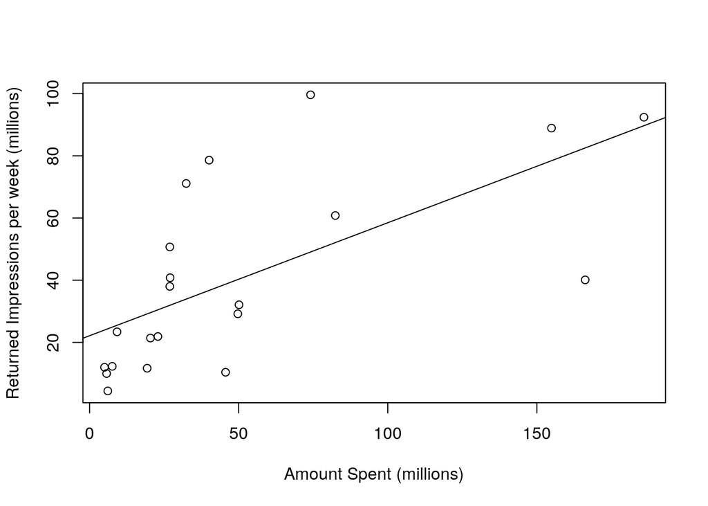

```r
MediaImpressionsLM
```

```
## $Summary
##
## Call:
## lm(formula = y ~ x, data = MediaImpressions$df)
##
## Residuals:
##     Min      1Q  Median      3Q     Max
## -42.422 -12.623  -8.171   8.832  50.526
##
## Coefficients:
##             Estimate Std. Error t value Pr(>|t|)
## (Intercept) 22.16269    7.08948   3.126  0.00556 **
## x            0.36317    0.09712   3.739  0.00139 **
## ---
## Signif. codes:  0 '***' 0.001 '**' 0.01 '*' 0.05 '.' 0.1 ' ' 1
##
## Residual standard error: 23.5 on 19 degrees of freedom
## Multiple R-squared:  0.424,  Adjusted R-squared:  0.3936
## F-statistic: 13.98 on 1 and 19 DF,  p-value: 0.001389
##
##
## $Anova
## Analysis of Variance Table
##
## Response: y
##           Df  Sum Sq Mean Sq F value   Pr(>F)
## x          1  7723.3  7723.3  13.983 0.001389 **
## Residuals 19 10494.1   552.3
## ---
## Signif. codes:  0 '***' 0.001 '**' 0.01 '*' 0.05 '.' 0.1 ' ' 1
##
## $MSres
## [1] 552.3215
##
## $RSqrd
## [1] 0.4239509
##
## $t_0
## [1] 3.739425
##
## $t_alpha
## [1] 2.079614
##
## $t_RejectNull
## [1] TRUE
##
## $fstatistic
## [1] 13.9833
##
## $pvalue
## [1] 0.001389084
##
## $Intercept
## [1] 22.16269
##
## $Slope
## [1] 0.3631741
```

### a

There seems to be a relationship there. The more money spent, the more impressions.

The relationship between money and impressions is the following:

Media Impressions = 0.3631741 * (Amount Spent) + 22.1626934

### b

With the F-statistics of 13.9833011 and a p value of 0.0013891 it is statistically significant. However with an R-squared of just 0.4239509 there is a lot of unexplained variance.

### c

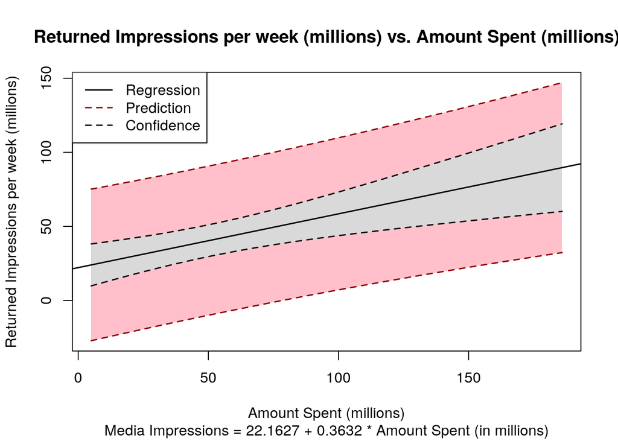

```r
PlotBands(MediaImpressions$df, MediaImpressions$lm,
          ylab="Returned Impressions per week (millions)", xlab="Amount Spent (millions)",
          main="Returned Impressions per week (millions) vs. Amount Spent (millions)",
          sub=paste("Media Impressions = ",round(MediaImpressionsLM$Intercept,4)," + ",round(MediaImpressionsLM$Slope,4)," * Amount Spent (in millions)",sep="")
          )
legend("topleft",
       legend=c("Regression","Prediction","Confidence"),
       col=c("black","red4","gray5"),
       lty=c("solid","dashed","dashed"),
       lwd=1.5
)
```

### d

```r
MCI_CI <- predict(MediaImpressions$lm, data.frame(x = c(26.9)), interval="confidence", level=0.95)
PointPrediction <- MCI_CI[1]
```

```r
x_0 <- 26.9
x_bar <- mean(MediaImpressions$df$x)
n <- nrow(MediaImpressions$df)
t_alpha <- qt(.975, df=(n-2))
S_xx <- sum(MediaImpressions$df$x^2) - ((sum(MediaImpressions$df$x))^2)/n
ConfIntervalOnMean_Above <- PointPrediction + t_alpha * (sqrt(MediaImpressionsLM$MSres * (1/n + ((x_0 - x_bar)^2)/S_xx)))
ConfIntervalOnMean_Below <- PointPrediction - t_alpha * (sqrt(MediaImpressionsLM$MSres * (1/n + ((x_0 - x_bar)^2)/S_xx)))
```

The predicted value of retained impressions from MCI at Spending Level of 26.9 is: 31.9321

The corresponding confidence interval is: ( 20.1831,43.681)

```r
MCI_PI <- predict(MediaImpressions$lm, data.frame(x = c(26.9)), interval="prediction", level=0.95)
```

```r
x_0 <- 26.9
x_bar <- mean(MediaImpressions$df$x)
n <- nrow(MediaImpressions$df)
t_alpha <- qt(.975, df=(n-2))
S_xx <- sum(MediaImpressions$df$x^2) - ((sum(MediaImpressions$df$x))^2)/n
PredictInterval_Above <- PointPrediction + t_alpha * (sqrt(MediaImpressionsLM$MSres * (1 + 1/n + ((x_0 - x_bar)^2)/S_xx)))
PredictInterval_Below <- PointPrediction - t_alpha * (sqrt(MediaImpressionsLM$MSres * (1 + 1/n + ((x_0 - x_bar)^2)/S_xx)))
```

The Prediction Interval for the number of retained impressions from MCI at Spending Level of 26.9 is: ( -18.6408,82.505) ## 2.19

```r
PatientSatAge <- list()

PatientSatAge$DataTable <- read_excel('../linear_regression_5e_data_sets/Appendices/data-table-B17.xls')

PatientSatAge$df <- data.frame(
    y=PatientSatAge$DataTable$'Satisfaction',
    x=PatientSatAge$DataTable$'Age')

head(PatientSatAge$df)
```

```
##    y  x
## 1 68 55
## 2 77 46
## 3 96 30
## 4 80 35
## 5 43 59
## 6 44 61
```

```r
PatientSatAge$lm <- lm(y ~ x, data=PatientSatAge$df)
```

```r
PatientSatAgeLM <- LMStandardAnalysis(PatientSatAge$df, PatientSatAge$lm, Probability = .975,
                                           ylab="Satisfaction", xlab="Age (years")
```

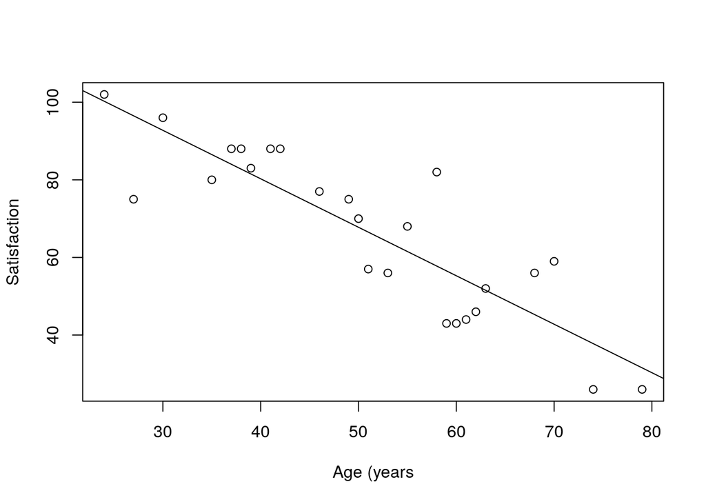

```r
PatientSatAgeLM
```

```
## $Summary
##
## Call:
## lm(formula = y ~ x, data = PatientSatAge$df)
##
## Residuals:
##     Min      1Q  Median      3Q     Max
## -21.497  -8.022   1.756   5.982  24.223
##
## Coefficients:
##             Estimate Std. Error t value Pr(>|t|)
## (Intercept) 130.2209     7.7775  16.743 2.24e-14 ***
## x            -1.2490     0.1471  -8.491 1.52e-08 ***
## ---
## Signif. codes:  0 '***' 0.001 '**' 0.01 '*' 0.05 '.' 0.1 ' ' 1
##
## Residual standard error: 10.67 on 23 degrees of freedom
## Multiple R-squared:  0.7581, Adjusted R-squared:  0.7476
## F-statistic: 72.09 on 1 and 23 DF,  p-value: 1.522e-08
##
##
## $Anova
## Analysis of Variance Table
##
## Response: y
##           Df Sum Sq Mean Sq F value    Pr(>F)
## x          1 8211.3  8211.3  72.091 1.522e-08 ***
## Residuals 23 2619.7   113.9
## ---
## Signif. codes:  0 '***' 0.001 '**' 0.01 '*' 0.05 '.' 0.1 ' ' 1
##
## $MSres
## [1] 113.9015
##
## $RSqrd
## [1] 0.7581271
##
## $t_0
## [1] -8.490657
##
## $t_alpha
## [1] 2.059539
##
## $t_RejectNull
## [1] TRUE
##
## $fstatistic
## [1] 72.09126
##
## $pvalue
## [1] 1.521773e-08
##
## $Intercept
## [1] 130.2209
##
## $Slope
## [1] -1.249035
```

### a

The equation for the model is : Satisfaction = 130.2209311 + -1.2490348 * Age

The model relating Satisfaction to Age provides a good fit with an R-squared value of 0.7581. Additionally the p-value is very small at 1.5217728^{-8} and the Residual Mean Squared term is 113.9015 and F-statistic of 72.0913

### b

The model relating Satisfaction to Age is a better fit than the original model in section 2.7 which had a Residual Mean Squared term of 270.02 and a F-statistic of 17.1114 vs. the values of 113.9015 and F-statistic of 72.0913

# 2.20

```r
FuelBoilingPoint <- list()

FuelBoilingPoint$DataTable <- read_excel('../linear_regression_5e_data_sets/Appendices/data-table-B18.xls')

FuelBoilingPoint$df <- data.frame(
    y=FuelBoilingPoint$DataTable$'y',
    x=FuelBoilingPoint$DataTable$'x_5')

head(FuelBoilingPoint$df)
```

```
##     y   x
## 1 343 220
## 2 356 220
## 3 344 223
## 4 356 223
## 5 352 221
## 6 361 221
```

```r
FuelBoilingPoint$lm <- lm(y ~ x, data=FuelBoilingPoint$df)
```

```r
FuelBoilingPointLM <- LMStandardAnalysis(FuelBoilingPoint$df, FuelBoilingPoint$lm, Probability = .975,
                                           ylab="Fuel Consumption", xlab="Fuel - Initial Boiling Point")
```

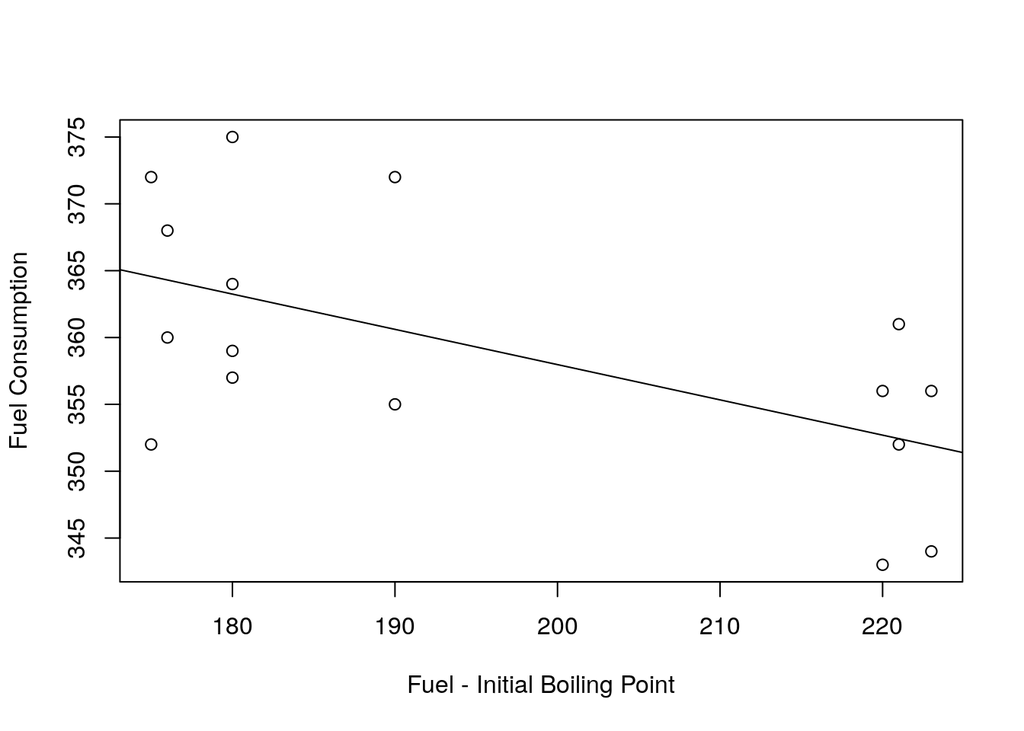

```r
FuelBoilingPointLM
```

```
## $Summary
##
## Call:
## lm(formula = y ~ x, data = FuelBoilingPoint$df)
##
## Residuals:
##      Min       1Q   Median       3Q      Max
## -12.5651  -5.7681   0.1608   4.9303  11.7537
##
## Coefficients:
##              Estimate Std. Error t value Pr(>|t|)
## (Intercept) 410.72319   18.92479  21.703 3.54e-12 ***
## x            -0.26376    0.09622  -2.741   0.0159 *
## ---
## Signif. codes:  0 '***' 0.001 '**' 0.01 '*' 0.05 '.' 0.1 ' ' 1
##
## Residual standard error: 7.838 on 14 degrees of freedom
## Multiple R-squared:  0.3493, Adjusted R-squared:  0.3028
## F-statistic: 7.514 on 1 and 14 DF,  p-value: 0.01592
##
##
## $Anova
## Analysis of Variance Table
##
## Response: y
##           Df Sum Sq Mean Sq F value  Pr(>F)
## x          1 461.65  461.65  7.5143 0.01592 *
## Residuals 14 860.10   61.44
## ---
## Signif. codes:  0 '***' 0.001 '**' 0.01 '*' 0.05 '.' 0.1 ' ' 1
##
## $MSres
## [1] 61.43592
##
## $RSqrd
## [1] 0.3492696
##
## $t_0
## [1] -2.74122
##
## $t_alpha
## [1] 2.119905
##
## $t_RejectNull
## [1] TRUE
##
## $fstatistic
## [1] 7.514287
##
## $pvalue
## [1] 0.01591697
##
## $Intercept
## [1] 410.7232
##
## $Slope
## [1] -0.2637607
```

The equation for the model is : FuelConsumption = 410.723185 + -0.2637607 * Fuel - Initial Boiling Point